# Summer Internship

Navin Ramanan

6/01/2022

##Setup

```
## Cortex: Running DESeq2 for Diet(Control vs Supplemented) with APP=APP, Age=3:padj < 0.05 and 0.10
```

```
## Cortex: APP3Control vs APP3Supplemented
```

```
## resultsNames:
```

```
##  [1] "Intercept"
##  [2] "group_APP12Supplemented_vs_APP12Control"
##  [3] "group_APP3Control_vs_APP12Control"
##  [4] "group_APP3Supplemented_vs_APP12Control"
##  [5] "group_APP6Control_vs_APP12Control"
##  [6] "group_APP6Supplemented_vs_APP12Control"
##  [7] "group_APP9Control_vs_APP12Control"
##  [8] "group_APP9Supplemented_vs_APP12Control"
##  [9] "group_WT12Control_vs_APP12Control"
## [10] "group_WT12Supplemented_vs_APP12Control"
## [11] "group_WT3Control_vs_APP12Control"
## [12] "group_WT3Supplemented_vs_APP12Control"
## [13] "group_WT6Control_vs_APP12Control"
## [14] "group_WT6Supplemented_vs_APP12Control"
## [15] "group_WT9Control_vs_APP12Control"
## [16] "group_WT9Supplemented_vs_APP12Control"
## [1] "group"            "APP3Control"      "APP3Supplemented"
##
## out of 34880 with nonzero total read count
## adjusted p-value < 0.1
## LFC > 0 (up)       : 4, 0.011%
## LFC < 0 (down)     : 0, 0%
## outliers [1]       : 101, 0.29%
## low counts [2]     : 0, 0%
## (mean count < 0)
## [1] see 'cooksCutoff' argument of ?results
## [2] see 'independentFiltering' argument of ?results
```

```
## log2 fold change (MLE): group APP3Control vs APP3Supplemented
## Wald test p-value: group APP3Control vs APP3Supplemented
## DataFrame with 10 rows and 6 columns
##                     baseMean log2FoldChange     lfcSE      stat      pvalue
##                    <numeric>      <numeric> <numeric> <numeric>   <numeric>
## ENSMUSG00000011034   3.84096      17.753764  2.678566   6.62809 3.40066e-11
## ENSMUSG00000110266   1.67263      17.779576  2.945294   6.03661 1.57390e-09
## ENSMUSG00000113104   4.37578       4.532772  0.952515   4.75874 1.94805e-06
## ENSMUSG00000046687  10.88512       2.767717  0.607867   4.55316 5.28455e-06
## ENSMUSG00000048620   2.42172      16.758894  3.897704   4.29968 1.71042e-05
## ENSMUSG00000109684   3.90939       4.331335  1.047254   4.13590 3.53569e-05
## ENSMUSG00000036480  11.04875       3.167170  0.791655   4.00069 6.31571e-05
## ENSMUSG00000103138   9.07949       2.294603  0.580249   3.95451 7.66904e-05
## ENSMUSG00000071531 150.57477       0.710252  0.182983   3.88152 1.03806e-04
## ENSMUSG00000087135   7.59487      -2.091660  0.545482  -3.83451 1.25813e-04
##                           padj
##                      <numeric>
## ENSMUSG00000011034 1.18272e-06
## ENSMUSG00000110266 2.73693e-05
## ENSMUSG00000113104 2.25837e-02
## ENSMUSG00000046687 4.59479e-02
## ENSMUSG00000048620 1.18973e-01
## ENSMUSG00000109684 2.04946e-01
## ENSMUSG00000036480 3.13792e-01
## ENSMUSG00000103138 3.33402e-01
## ENSMUSG00000071531 4.01141e-01
## ENSMUSG00000087135 4.37564e-01
```

```
## log2 fold change (MLE): group APP3Control vs APP3Supplemented
## Wald test p-value: group APP3Control vs APP3Supplemented
## DataFrame with 34880 rows and 6 columns
##                       baseMean log2FoldChange     lfcSE      stat      pvalue
##                      <numeric>      <numeric> <numeric> <numeric>   <numeric>
## ENSMUSG00000011034     3.84096       17.75376  2.678566   6.62809 3.40066e-11
## ENSMUSG00000110266     1.67263       17.77958  2.945294   6.03661 1.57390e-09
## ENSMUSG00000113104     4.37578        4.53277  0.952515   4.75874 1.94805e-06
## ENSMUSG00000046687    10.88512        2.76772  0.607867   4.55316 5.28455e-06
## ENSMUSG00000048620     2.42172       16.75889  3.897704   4.29968 1.71042e-05
## ...                        ...            ...       ...       ...         ...
## ENSMUSG00000109212    0.769426       0.000000  8.245409  0.000000          NA
## ENSMUSG00000054134   40.269651       0.116311  0.760060  0.153029          NA
## ENSMUSG00000024028    0.789155       0.000000  8.245409  0.000000          NA
## ENSMUSG00000061808 1664.189531       0.905649  0.829783  1.091429          NA
## ENSMUSG00000037451    1.547250       0.000000  8.245409  0.000000          NA
##                           padj
##                      <numeric>
## ENSMUSG00000011034 1.18272e-06
## ENSMUSG00000110266 2.73693e-05
## ENSMUSG00000113104 2.25837e-02
## ENSMUSG00000046687 4.59479e-02
## ENSMUSG00000048620 1.18973e-01
## ...                        ...
## ENSMUSG00000109212          NA
## ENSMUSG00000054134          NA
## ENSMUSG00000024028          NA
## ENSMUSG00000061808          NA
## ENSMUSG00000037451          NA
```

```
## class: DESeqDataSet
## dim: 34880 96
## metadata(1): version
## assays(4): counts mu H cooks
## rownames(34880): ENSMUSG00000102628 ENSMUSG00000097426 ...
##   ENSMUSG00000095041 ENSMUSG00000095742
## rowData names(78): baseMean baseVar ... deviance maxCooks
## colnames(96): 102 103 ... 95 96
## colData names(6): Sex Diet ... group sizeFactor
```

```
## Cortex DESeq2 result is saved in file: 'Cortex_deseq_results_Diet_APP_3.csv'
```

```
## Cortex DESeq2 normalized counts is saved in file: 'Cortex_deseq_norm_counts_Diet_APP_3.csv'
```

```
## Cortex DESeq2 result with Gene names (mgi_symbols) is saved in file: 'Cortex_deseq_results_with_genename_Diet_APP_3.csv'
```

```
## [1] 34880
```

```
## [1] 4
```

```
## Cortex DESeq2 result after padj (0.05) filtering is saved in file: 'Cortex_deseq_results_Diet_APP_3_padj_05_filtered.csv'
```

```
## Number of DE genes significant at padj < 0.05 for Cortex:APP3Control vs APP3Supplemented: 4
```

```
## Number of DE genes discarded after padj threshold 0.05 filtering for Cortex:APP3Control vs APP3Supplemented: 34876
```

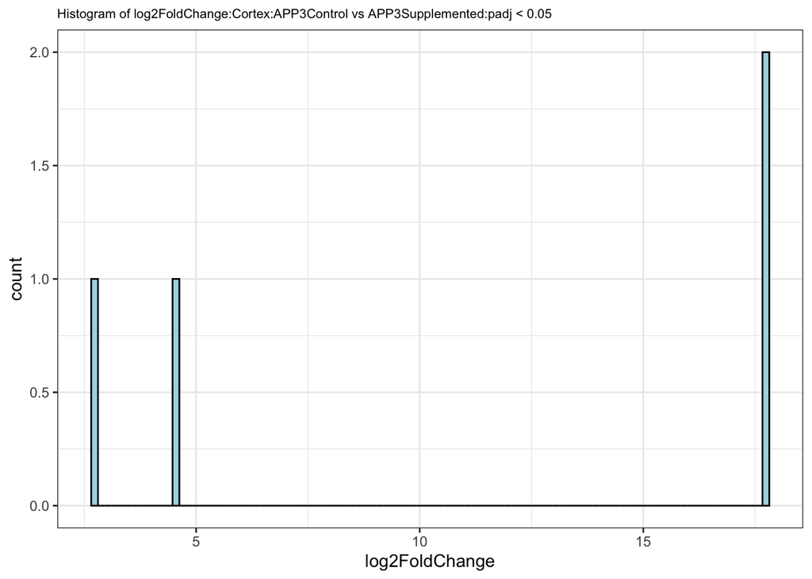

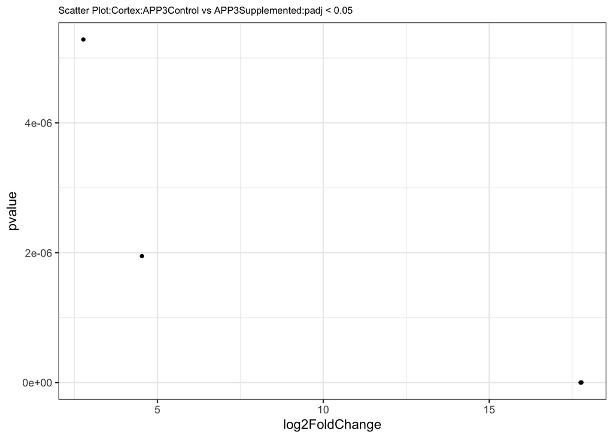

```
## [1] 34880
```

```
## [1] 4
```

```
## Cortex DESeq2 result after padj (0.1) filtering is saved in file: 'Cortex_deseq_results_Diet_APP_3_padj_1_filtered.csv'
```

```
## Number of DE genes significant at padj < 0.1 for Cortex:APP3Control vs APP3Supplemented: 4
```

```
## Number of DE genes discarded after padj threshold 0.1 filtering for Cortex:APP3Control vs APP3Supplemented: 34876
```

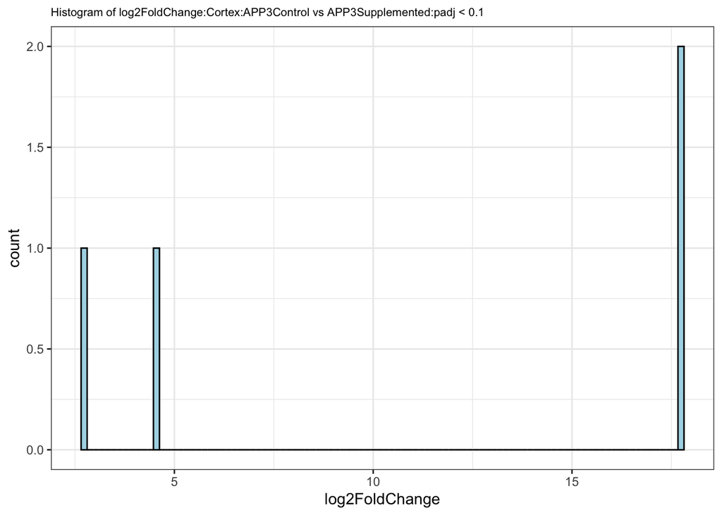

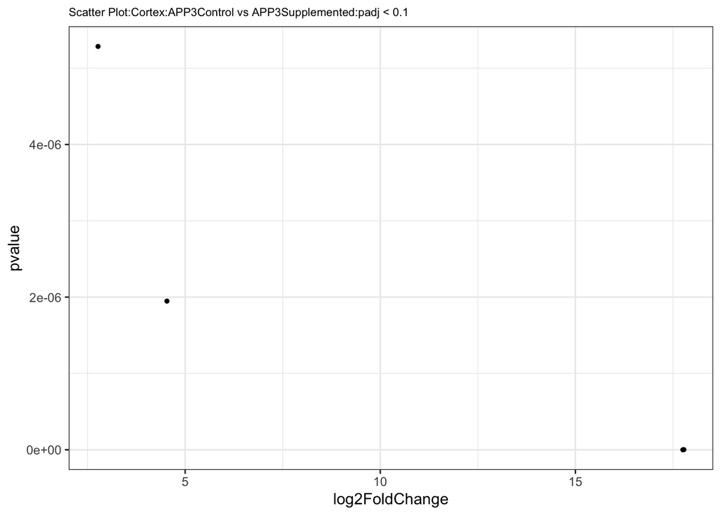

6. Cortex: Enhanced Volcano Plot

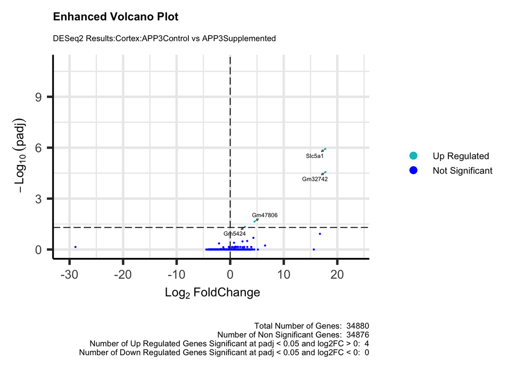

7. Cortex: Heatmap

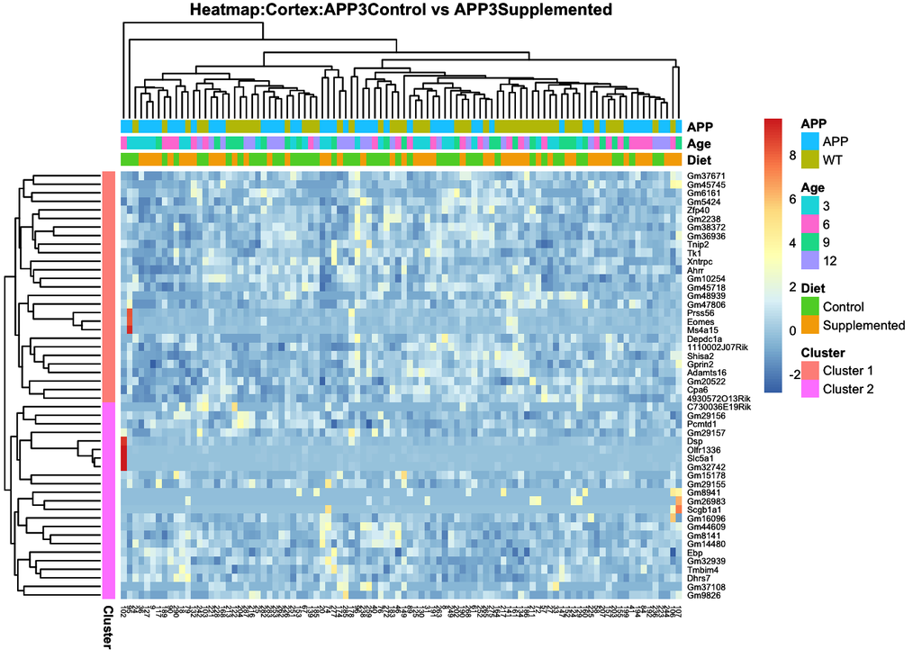

```
## Hippocampus: Running DESeq2 for Diet(Control vs Supplemented) with APP=APP, Age=3:padj < 0.05 and 0.10
```

```
## Hippocampus: APP3Control vs APP3Supplemented
```

```
## resultsNames:
```

```
##  [1] "Intercept"
##  [2] "group_APP12Supplemented_vs_APP12Control"
##  [3] "group_APP3Control_vs_APP12Control"
##  [4] "group_APP3Supplemented_vs_APP12Control"
##  [5] "group_APP6Control_vs_APP12Control"
##  [6] "group_APP6Supplemented_vs_APP12Control"
##  [7] "group_APP9Control_vs_APP12Control"
##  [8] "group_APP9Supplemented_vs_APP12Control"
##  [9] "group_WT12Control_vs_APP12Control"
## [10] "group_WT12Supplemented_vs_APP12Control"
## [11] "group_WT3Control_vs_APP12Control"
## [12] "group_WT3Supplemented_vs_APP12Control"
## [13] "group_WT6Control_vs_APP12Control"
## [14] "group_WT6Supplemented_vs_APP12Control"
## [15] "group_WT9Control_vs_APP12Control"
## [16] "group_WT9Supplemented_vs_APP12Control"
## [1] "group"            "APP3Control"      "APP3Supplemented"
##
## out of 33271 with nonzero total read count
## adjusted p-value < 0.1
## LFC > 0 (up)       : 2, 0.006%
## LFC < 0 (down)     : 3, 0.009%
## outliers [1]       : 77, 0.23%
## low counts [2]     : 0, 0%
## (mean count < 0)
## [1] see 'cooksCutoff' argument of ?results
## [2] see 'independentFiltering' argument of ?results
```

```
## log2 fold change (MLE): group APP3Control vs APP3Supplemented
## Wald test p-value: group APP3Control vs APP3Supplemented
## DataFrame with 10 rows and 6 columns
##                     baseMean log2FoldChange     lfcSE      stat      pvalue
##                    <numeric>      <numeric> <numeric> <numeric>   <numeric>
## ENSMUSG00000079466   2.88140      -22.83832  2.353230  -9.70510 2.86809e-22
## ENSMUSG00000066720   5.43956       20.87131  2.787897   7.48640 7.07880e-14
## ENSMUSG00000031654  98.29728       -1.84680  0.357355  -5.16797 2.36650e-07
## ENSMUSG00000024027 151.09163       -2.34137  0.461685  -5.07136 3.94992e-07
## ENSMUSG00000078853 301.99131        2.15634  0.470095   4.58704 4.49575e-06
## ENSMUSG00000034127   8.25144       -4.70860  1.136568  -4.14282 3.43060e-05
## ENSMUSG00000048126  72.44529       -1.75170  0.429839  -4.07524 4.59677e-05
## ENSMUSG00000042501   8.76935       -3.25314  0.826547  -3.93582 8.29139e-05
## ENSMUSG00000105597   2.93857       -4.68744  1.191407  -3.93437 8.34143e-05
## ENSMUSG00000028270 402.12889        1.74815  0.446438   3.91578 9.01131e-05
##                           padj
##                      <numeric>
## ENSMUSG00000079466 9.52033e-18
## ENSMUSG00000066720 1.17487e-09
## ENSMUSG00000031654 2.61846e-03
## ENSMUSG00000024027 3.27784e-03
## ENSMUSG00000078853 2.98464e-02
## ENSMUSG00000034127 1.89792e-01
## ENSMUSG00000048126 2.17979e-01
## ENSMUSG00000042501 2.30094e-01
## ENSMUSG00000105597 2.30094e-01
## ENSMUSG00000028270 2.30094e-01
```

```
## log2 fold change (MLE): group APP3Control vs APP3Supplemented
## Wald test p-value: group APP3Control vs APP3Supplemented
## DataFrame with 33271 rows and 6 columns
##                       baseMean log2FoldChange     lfcSE      stat      pvalue
##                      <numeric>      <numeric> <numeric> <numeric>   <numeric>
## ENSMUSG00000079466     2.88140      -22.83832  2.353230  -9.70510 2.86809e-22
## ENSMUSG00000066720     5.43956       20.87131  2.787897   7.48640 7.07880e-14
## ENSMUSG00000031654    98.29728       -1.84680  0.357355  -5.16797 2.36650e-07
## ENSMUSG00000024027   151.09163       -2.34137  0.461685  -5.07136 3.94992e-07
## ENSMUSG00000078853   301.99131        2.15634  0.470095   4.58704 4.49575e-06
## ...                        ...            ...       ...       ...         ...
## ENSMUSG00000068196   434.29152        3.92019   1.19812  3.271964          NA
## ENSMUSG00000053375     1.58633        2.70570   3.23020  0.837625          NA
## ENSMUSG00000023122    38.89638        6.04908   2.56704  2.356444          NA
## ENSMUSG00000023943    18.46229        5.56606   2.72344  2.043763          NA
## ENSMUSG00000061808 34756.71162        7.93314   1.53505  5.168011          NA
##                           padj
##                      <numeric>
## ENSMUSG00000079466 9.52033e-18
## ENSMUSG00000066720 1.17487e-09
## ENSMUSG00000031654 2.61846e-03
## ENSMUSG00000024027 3.27784e-03
## ENSMUSG00000078853 2.98464e-02
## ...                        ...
## ENSMUSG00000068196          NA
## ENSMUSG00000053375          NA
## ENSMUSG00000023122          NA
## ENSMUSG00000023943          NA
## ENSMUSG00000061808          NA
```

```
## class: DESeqDataSet
## dim: 33271 96
## metadata(1): version
## assays(4): counts mu H cooks
## rownames(33271): ENSMUSG00000102628 ENSMUSG00000086053 ...
##   ENSMUSG00000095041 ENSMUSG00000095742
## rowData names(78): baseMean baseVar ... deviance maxCooks
## colnames(96): 102 103 ... 95 96
## colData names(6): Sex Diet ... group sizeFactor
```

```
## Hippocampus DESeq2 result is saved in file: 'Hippocampus_deseq_results_Diet_APP_3.csv'
```

```
## Hippocampus DESeq2 normalized counts is saved in file: 'Hippocampus_deseq_norm_counts_Diet_APP_3.csv'
```

```
## Hippocampus DESeq2 result with Gene names (mgi_symbols) is saved in file: 'Hippocampus_deseq_results_with_genename_Diet_APP_3.csv'
```

```
## Hippocampus DESeq2 result after padj (0.05) filtering is saved in file: 'Hippocampus_deseq_results_Diet_APP_3_padj_05_filtered.csv'
```

```
## Number of DE genes significant at padj < 0.05 for Hippocampus:APP3Control vs APP3Supplemented: 5
```

```
## Number of DE genes discarded after padj threshold < 0.05 filtering for Hippocampus:APP3Control vs APP3Supplemented: 33266
```

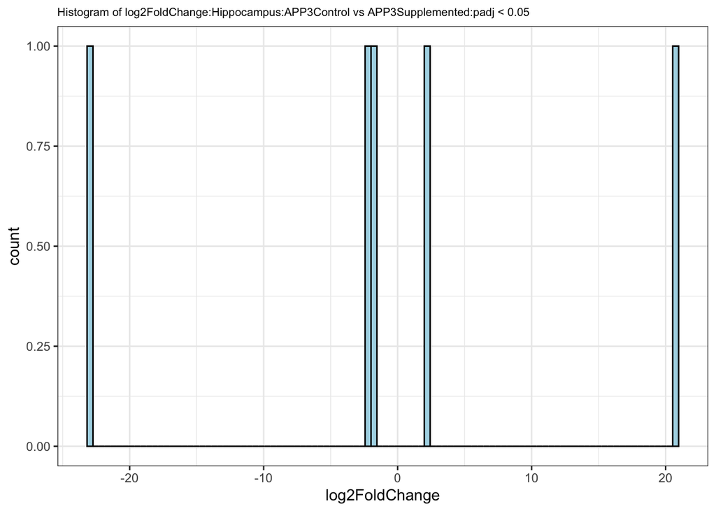

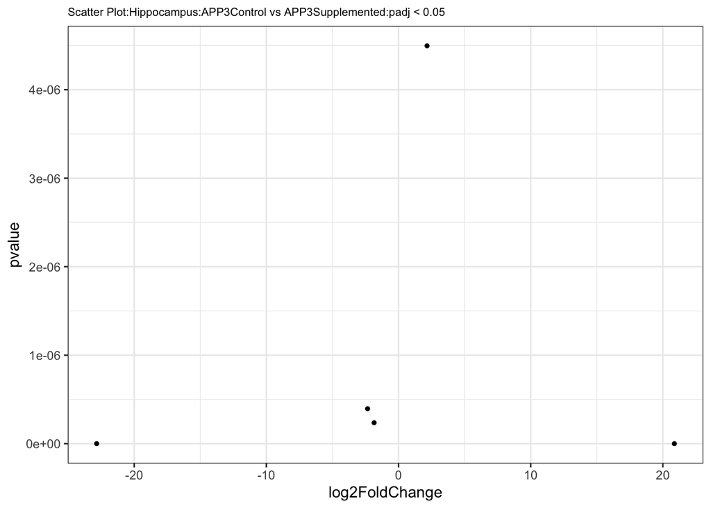

```
## Hippocampus DESeq2 result after padj (0.1) filtering is saved in file: 'Hippocampus_deseq_results_Diet_APP_3_padj_1_filtered.csv'
```

```
## Number of DE genes significant at padj < 0.1 for Hippocampus:APP3Control vs APP3Supplemented: 5
```

```
## Number of DE genes discarded after padj threshold < 0.1 filtering for Hippocampus:APP3Control vs APP3Supplemented: 33266
```

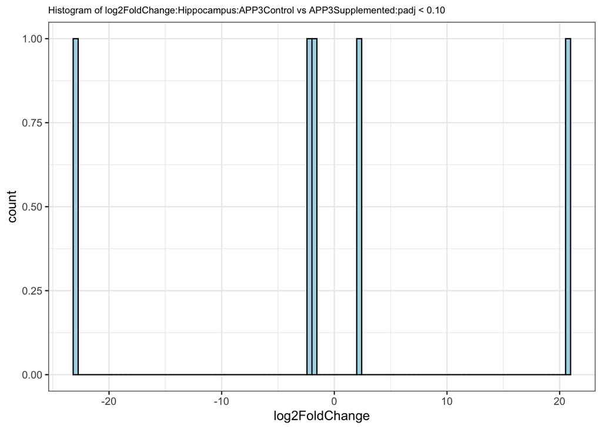

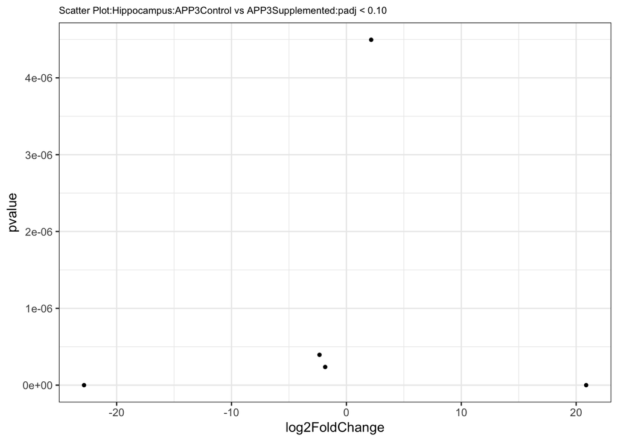

9. Hippocampus: Enhanced Volcano Plot

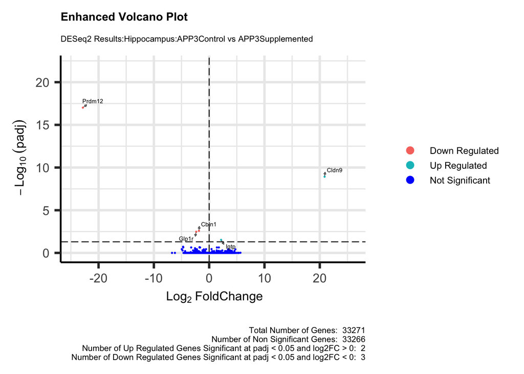

10. Hippocampus: Heatmap

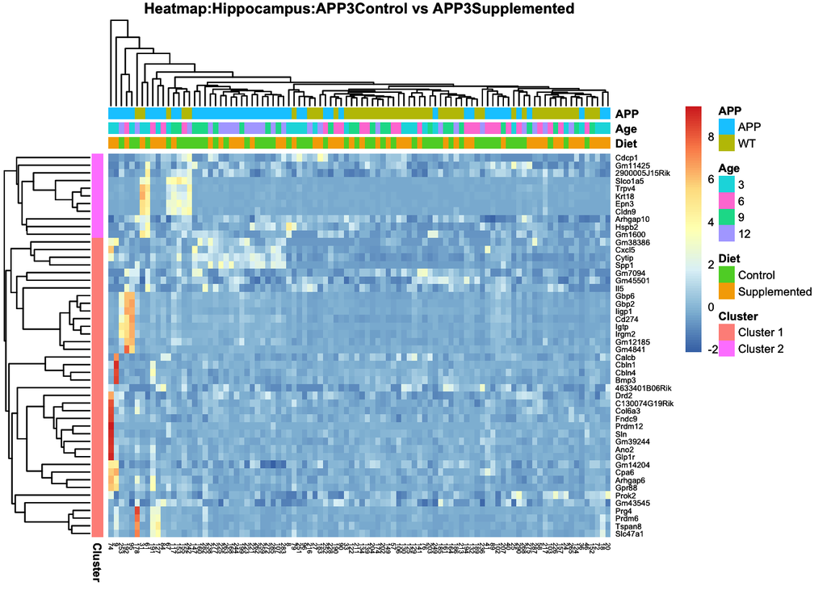

11. GSEA:Running fgsea

Perform a GSEA using a ranked list log2FoldChange values for all genes discovered in the DESeq2 results against the M2 Canonical Pathways gene set collection. Convert gene identifiers in the results to the appropriate matching format found in the M2 gene sets. fgsea expects a named vector of gene level statistics and the gene sets in the form of a named list.

Using “m2.cp.wikipathways.v0.3.symbols.gmt” which is the Canonical Pathways gene sets derived from the WikiPathways pathway database (WikiPathways subset of CP)

```
## # A tibble: 34,880 × 8
##    genes              volc_plot_s…¹ log2F…²    padj baseM…³ lfcSE  stat   pvalue
##    <chr>              <chr>           <dbl>   <dbl>   <dbl> <dbl> <dbl>    <dbl>
##  1 ENSMUSG00000011034 UP             17.8   1.18e-6    3.84 2.68   6.63 3.40e-11
##  2 ENSMUSG00000110266 UP             17.8   2.74e-5    1.67 2.95   6.04 1.57e- 9
##  3 ENSMUSG00000113104 UP              4.53  2.26e-2    4.38 0.953  4.76 1.95e- 6
##  4 ENSMUSG00000046687 UP              2.77  4.59e-2   10.9  0.608  4.55 5.28e- 6
##  5 ENSMUSG00000048620 NS             16.8   1.19e-1    2.42 3.90   4.30 1.71e- 5
##  6 ENSMUSG00000109684 NS              4.33  2.05e-1    3.91 1.05   4.14 3.54e- 5
##  7 ENSMUSG00000036480 NS              3.17  3.14e-1   11.0  0.792  4.00 6.32e- 5
##  8 ENSMUSG00000103138 NS              2.29  3.33e-1    9.08 0.580  3.95 7.67e- 5
##  9 ENSMUSG00000071531 NS              0.710 4.01e-1  151.   0.183  3.88 1.04e- 4
## 10 ENSMUSG00000087135 NS             -2.09  4.38e-1    7.59 0.545 -3.83 1.26e- 4
## # … with 34,870 more rows, and abbreviated variable names ¹volc_plot_status,
## #   ²log2FoldChange, ³baseMean
## # ℹ Use `print(n = ...)` to see more rows
```

```
## # A tibble: 190 × 8
##    pathway                       pval    padj log2err     ES   NES  size leadi…¹
##    <chr>                        <dbl>   <dbl>   <dbl>  <dbl> <dbl> <int> <list>
##  1 WP_PROSTAGLANDIN_SYNTHESI… 3.73e-5 0.00354   0.557 -0.825 -2.08    31 <chr>
##  2 WP_ELECTRON_TRANSPORT_CHA… 2.17e-5 0.00354   0.576 -0.635 -1.92    97 <chr>
##  3 WP_CYTOPLASMIC_RIBOSOMAL_… 8.50e-4 0.0539    0.477 -0.614 -1.83    90 <chr>
##  4 WP_OXIDATIVE_PHOSPHORYLAT… 4.48e-3 0.213     0.407 -0.571 -1.60    59 <chr>
##  5 WP_TCA_CYCLE               4.14e-2 1         0.322 -0.588 -1.49    31 <chr>
##  6 WP_LUNG_FIBROSIS           1.98e-2 0.754     0.352 -0.523 -1.47    61 <chr>
##  7 WP_PROTEASOME_DEGRADATION  3.50e-2 1         0.322 -0.535 -1.47    51 <chr>
##  8 WP_OSTEOBLAST_SIGNALING    1.36e-1 1         0.174 -0.703 -1.34     9 <chr>
##  9 WP_EDA_SIGNALING_IN_HAIR_… 1.23e-1 1         0.183 -0.577 -1.31    18 <chr>
## 10 WP_FATTY_ACID_OMEGAOXIDAT… 2.06e-1 1         0.141 -0.737 -1.27     6 <chr>
## # … with 180 more rows, and abbreviated variable name ¹leadingEdge
## # ℹ Use `print(n = ...)` to see more rows
```

```
## Cortex NES ordered fgsea results saved in file: 'Cortex_NES_ordered_fgsea_results_Diet_APP_3_FC0.csv'
```

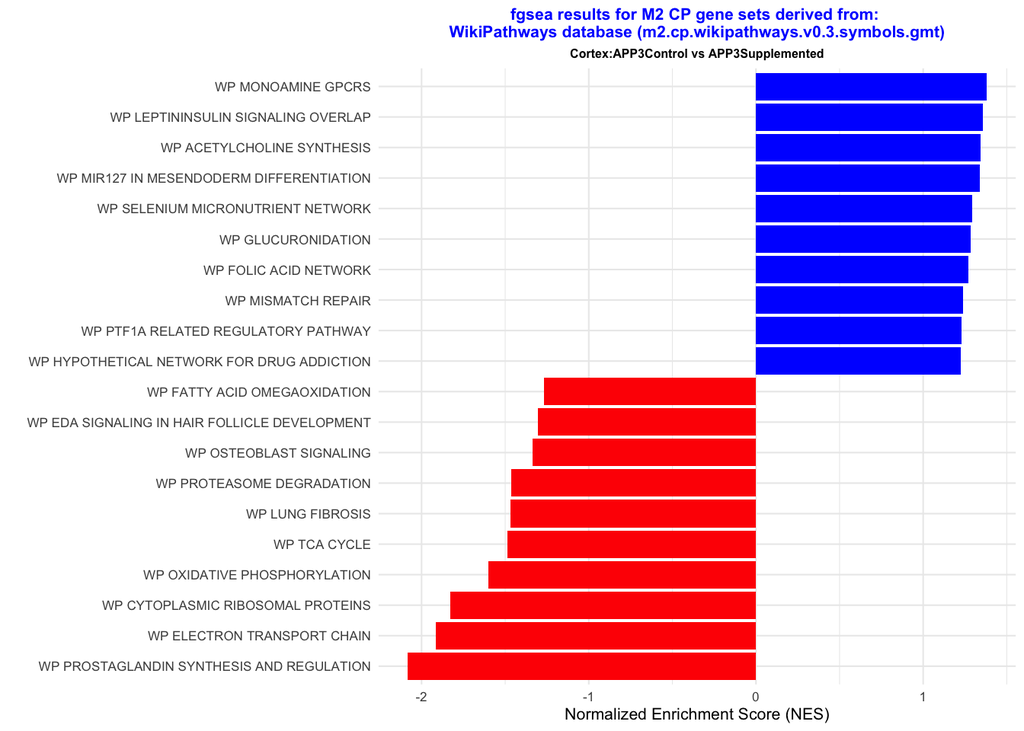

```
## # A tibble: 33,271 × 8
##    genes              volc_plot_…¹ log2F…²     padj baseM…³ lfcSE  stat   pvalue
##    <chr>              <chr>          <dbl>    <dbl>   <dbl> <dbl> <dbl>    <dbl>
##  1 ENSMUSG00000079466 DOWN          -22.8  9.52e-18    2.88 2.35  -9.71 2.87e-22
##  2 ENSMUSG00000066720 UP             20.9  1.17e- 9    5.44 2.79   7.49 7.08e-14
##  3 ENSMUSG00000031654 DOWN           -1.85 2.62e- 3   98.3  0.357 -5.17 2.37e- 7
##  4 ENSMUSG00000024027 DOWN           -2.34 3.28e- 3  151.   0.462 -5.07 3.95e- 7
##  5 ENSMUSG00000078853 UP              2.16 2.98e- 2  302.   0.470  4.59 4.50e- 6
##  6 ENSMUSG00000034127 NS             -4.71 1.90e- 1    8.25 1.14  -4.14 3.43e- 5
##  7 ENSMUSG00000048126 NS             -1.75 2.18e- 1   72.4  0.430 -4.08 4.60e- 5
##  8 ENSMUSG00000042501 NS             -3.25 2.30e- 1    8.77 0.827 -3.94 8.29e- 5
##  9 ENSMUSG00000105597 NS             -4.69 2.30e- 1    2.94 1.19  -3.93 8.34e- 5
## 10 ENSMUSG00000028270 NS              1.75 2.30e- 1  402.   0.446  3.92 9.01e- 5
## # … with 33,261 more rows, and abbreviated variable names ¹volc_plot_status,
## #   ²log2FoldChange, ³baseMean
## # ℹ Use `print(n = ...)` to see more rows
```

```
## # A tibble: 190 × 8
##    pathway                         pval  padj log2err     ES   NES  size leadi…¹
##    <chr>                          <dbl> <dbl>   <dbl>  <dbl> <dbl> <int> <list>
##  1 WP_TRYPTOPHAN_METABOLISM     0.00244 0.463   0.432 -0.617 -1.68    42 <chr>
##  2 WP_GPCRS_CLASS_B_SECRETINLI… 0.0196  0.865   0.352 -0.659 -1.58    22 <chr>
##  3 WP_HEART_DEVELOPMENT         0.0113  0.865   0.381 -0.597 -1.57    36 <chr>
##  4 WP_GLUCURONIDATION           0.0728  0.865   0.231 -0.739 -1.44     9 <chr>
##  5 WP_FATTY_ACID_OMEGAOXIDATION 0.125   0.865   0.181 -0.786 -1.37     6 <chr>
##  6 WP_ESTROGEN_METABOLISM       0.119   0.865   0.178 -0.701 -1.37     9 <chr>
##  7 WP_HYPOXIADEPENDENT_SELFREN… 0.140   0.865   0.166 -0.622 -1.32    13 <chr>
##  8 WP_EICOSANOID_METABOLISM_VI… 0.157   0.865   0.156 -0.700 -1.31     8 <chr>
##  9 WP_STEROID_BIOSYNTHESIS      0.159   0.865   0.152 -0.670 -1.30     9 <chr>
## 10 WP_GPCRS_PEPTIDE             0.0644  0.865   0.262 -0.439 -1.29    69 <chr>
## # … with 180 more rows, and abbreviated variable name ¹leadingEdge
## # ℹ Use `print(n = ...)` to see more rows
```

```
## Hippocampus NES ordered fgsea results saved in file: 'Hippocampus_NES_ordered_fgsea_results_Diet_APP_3_FC0.csv'
```

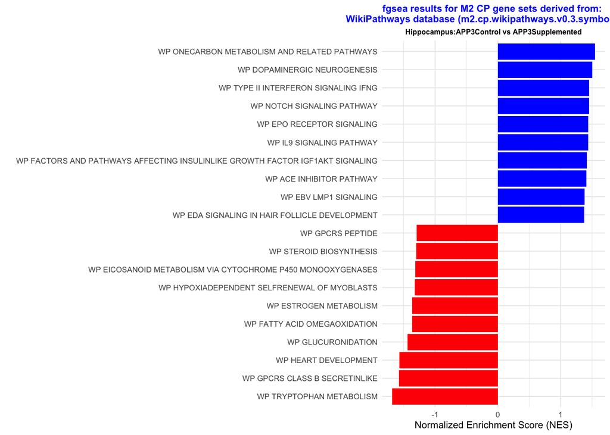